# SMART Indicator Report: Inshore Survey (New England)

## Indicator name

Inshore Survey (New England)

Includes variable(s): Apex Predator Fall, Apex Predator Spring, Benthivore Fall, Benthivore Spring, Benthos Fall, Benthos Spring, Other Fall, Other Spring, Piscivore Fall, Piscivore Spring, Planktivore Fall, Planktivore Spring

## Indicator brief description

Biomass time series for aggregate species groups from the Maine/New Hampshire inshore bottom trawl surveys conducted in Maine and New Hampshire state waters.

## Indicator visualization

Each survey shows trends by aggregate group.

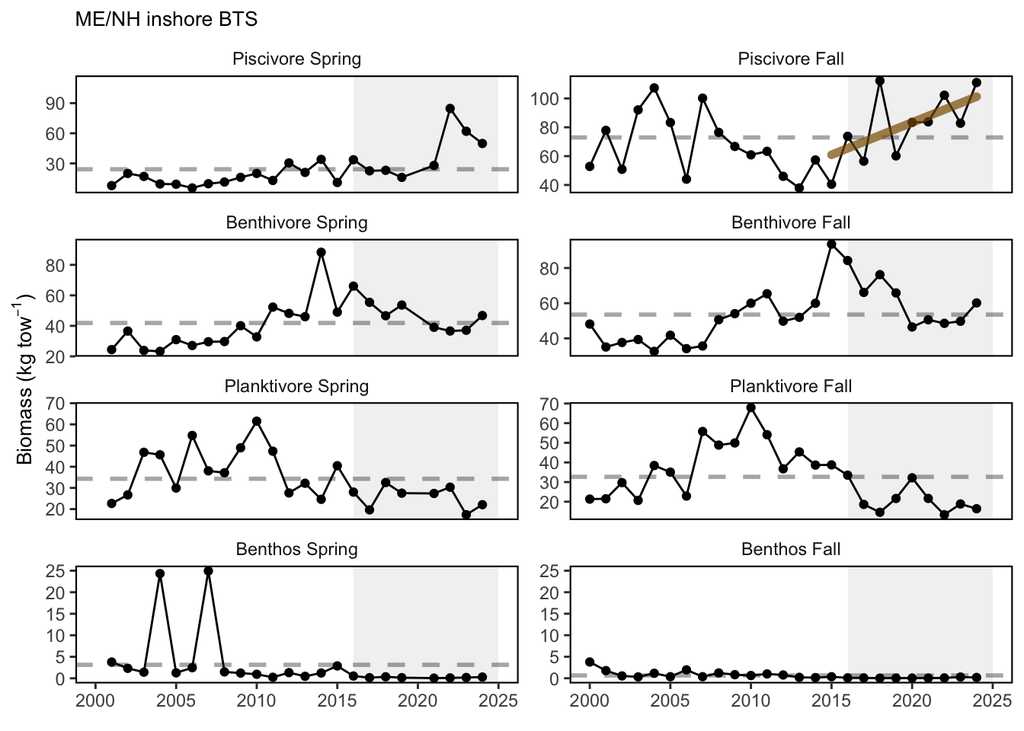

## Indicator documentation

### Are indicators available for others to use (data downloadable)?

```
## Yes
```

#### Where can indicators be found?

```
## Data: https://noaa-edab.github.io/ecodata/index.html
## Description:  https://noaa-edab.github.io/catalog/ne_inshore_survey.html
## Technical documentation:  https://noaa-edab.github.io/tech-doc/ne_inshore_survey.html
```

#### Who is the contact?

Rebecca Peters (ME/NH survey), rebecca.j.peters@maine.gov

### Gather indicator statistics

#### Units

```
## (KG/tow)
```

#### Length of time series, start and end date, periodicity

General overview: Spring and Fall

Indicator specifics:

| Indicator | EPU | StartYear | EndYear | NumYears | MissingYears |
| --- | --- | --- | --- | --- | --- |
| Apex Predator Fall | NE | 2000 | 2024 | 25 | 0 |
| Apex Predator Spring | NE | 2001 | 2024 | 23 | 1 |
| Benthivore Fall | NE | 2000 | 2024 | 25 | 0 |
| Benthivore Spring | NE | 2001 | 2024 | 23 | 1 |
| Benthos Fall | NE | 2000 | 2024 | 25 | 0 |
| Benthos Spring | NE | 2001 | 2024 | 23 | 1 |
| Other Fall | NE | 2000 | 2024 | 25 | 0 |
| Other Spring | NE | 2001 | 2024 | 23 | 1 |
| Piscivore Fall | NE | 2000 | 2024 | 25 | 0 |
| Piscivore Spring | NE | 2001 | 2024 | 23 | 1 |
| Planktivore Fall | NE | 2000 | 2024 | 25 | 0 |
| Planktivore Spring | NE | 2001 | 2024 | 23 | 1 |

#### Spatial location, scale and extent

General overview: Nearshore regions of the MAB and GOM

Indicator specifics:

| Indicator | EPU |
| --- | --- |
| Apex Predator Fall | NE |
| Apex Predator Spring | NE |
| Benthivore Fall | NE |
| Benthivore Spring | NE |
| Benthos Fall | NE |
| Benthos Spring | NE |
| Other Fall | NE |
| Other Spring | NE |
| Piscivore Fall | NE |
| Piscivore Spring | NE |
| Planktivore Fall | NE |
| Planktivore Spring | NE |

### Are methods clearly documented to obtain source data and calculate indicators?

```
## Yes
```

## Indicator analysis/testing or history of use

### What decision or advice processes are the indicators currently used in?

Indicators from these inshore surveys are analogous to those produced by the NEFSC trawl survey in the aggregate survey biomass indicator dataset.

### What implications of the indicators are currently listed?

The trends in the Maine/New Hampshire inshore survey vary compared to the NEFSC survey. This is driven by different species availability to surveys in time and space as well as the surveys sampling different habitats. Nearshore habitats are important to fish and fisheries so we monitor them as as well as trends from the larger EPUs.

## Comments

### Additional potential links to management in addition to uses listed above

### What additional work would be needed for the Council to use the indicator?

### What issues are caused if there is a gap or delay in data underlying the indicator